# DATA622_FP

Group 5

2021-05-19

## Authorship

**Group 5:**

- Don (Geeth) Padmaperuma,
- Subhalaxmi Rout,
- Isabel Ramesar, and
- Magnus Skonberg

# Background

The purpose of our Final Project was to explore the application of Neural Networks to loan approval data to then back compare model performance with a variety of Classification algorithms (ie. KNN, DT, RF, GBM).

## Neural Networks

Neural networks form the basis of Deep Learning, an extension of Machine Learning, where algorithms are inspired by the structure of the human brain. They take in data, train themselves to recognize patterns therein, and then predict outputs for similar, unseen data.

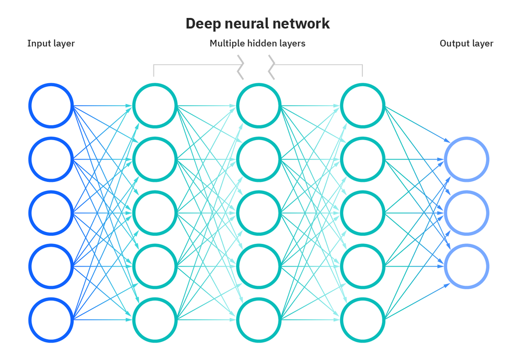

```r
download.file(
    url='https://1.cms.s81c.com/sites/default/files/2021-01-06/ICLH_Diagram_Batch_01_03-DeepNeuralNetwork-WHITEBG.png',
    destfile='image1.jpg',
    mode='wb')
knitr::include_graphics(path='image1.jpg')
```

Neural networks are made up of layers of nodes. They contain an input layer, one or more hidden layers, and an output layer. Nodes are interconnected with associated weights and thresholds. When a node is above its specified threshold, the node is activated and data is sent to the next layer of the network. Otherwise, data is not fed forward.

The power of a neural network lies in its ability to fine-tune upon countless iterations. *Back-propagation* allows for continuous model accuracy improvement. Weights are adjusted based on the magnitude of error at the output layer, and continuous refinement allows for predictive accuracy improvements.

## Our Approach

We’ll explore and prepare the loan dataset, train multiple neural network and alternative classification models and then compare and contrast the top performing model from each group in its ability to accurately classify `Loan_Status` (approval/ rejection).

# Loan Approval Data

A loan is when money is transferred from one party to another under the prospect that the lender (loan giver) will be repaid in full *with interest* by the lendee (loan receiver).

The profit, for the lendor, comes from the interest they are paid by the lendee and thus, as a core part of their business model, it’s important for banks and credit companies alike to be able to depend upon the fact that their loan (and interest) will be repaid in full.

With this motivation in mind, we (re) explore and prepare our loan approval dataset in order to construct a more precise neural network model (later). Being that we’ve explored this data before, we build upon the core takeaways of our past exploration while simultaneously pushing the bounds of our understanding to a deeper level. *Rudimentary (early) EDA steps will be summarized and/or excluded from the write up and included in the Appendix in favor of output that provides greater context and insight.*

Prior to commencing EDA, we revisit the corresponding data directory:

- `LoanID`: unique loan ID
- `Gender`: applicant gender (Male/Female)
- `Married`: applicant marriage status (Yes/No)
- `Dependents`: number of dependents for applicant (0, 1, 2, 3+)
- `Education`: applicant college education status (Graduate / Not Graduate)
- `Self_Employed`: applicant self-employment status (Yes/No)
- `ApplicantIncome`: applicant income level
- `CoapplicantIncome`: co-applicant income level (if applicable)
- `LoanAmount`: loan amount requested (in thousands)
- `Loan_Amount_Term`: loan term (in months)
- `Credit_History`: credit history meets guidelines (1/0)
- `PropertyArea`: property location (Urban/Semi Urban/Rural)
- `Loan_Status`: loan approved (Yes/No). **target variable**

# Data Exploration & Preparation

To start, we load in our data, replace empty strings with NAs, observe the first 6 observations of our dataset to refamiliarize ourselves with the format of our data and then use R’s built-in glimpse() and summary() functions to revisit data types and value ranges.

We’re dealing with a 614 observation x 13 variable dataframe with `Loan_Status` as our dependent, categoric variable, `ApplicantIncome`, `CoApplicantIncome`,`LoanAmount`, `Loan_Amount_Term`, and `Credit_History` as independent, numeric variables, and `Loan_ID`, `LoanGender`, `Married`, `Dependents`, `Education`, `Self_Employed`, `Property_Area`, and `Loan_Status` as independent, categoric variables.

From above, we extend that `Loan_ID` can be dropped, `ApplicantIncome` and `CoApplicantIncome` can be combined to create a `TotalIncome` variable, and observations with a “3+” label in `Dependents` should be re-labelled as “3” so that data follows a consistent format and imputation can be performed as a next step.

## NA Values

We pre-process our data (as described above), visualize and handle NA values:

```r
#Pre-process dataset for easier interpretation
loan <- subset(loan, select = -c(1) ) #drop Loan_ID from consideration
loan$TotalIncome <- loan$CoapplicantIncome + loan$ApplicantIncome #create TotalIncome variable
loan <- subset(loan, select = -c(6,7) ) #drop CoapplicantIncome and ApplicantIncome
loan$Dependents <- revalue(loan$Dependents, c("3+"="3")) #relabel Dependents "3+" value as "3"

#Visualize NA counts
colSums(is.na(loan))
```

```
##           Gender          Married       Dependents        Education
##               13                3               15                0
##    Self_Employed       LoanAmount Loan_Amount_Term   Credit_History
##               32               22               14               50
##    Property_Area      Loan_Status      TotalIncome
##                0                0                0
```

We re-assign the “3+” value of the `Dependents` variable to provide consistent leveling and enable **pmm** (predictive mean matching). Predictive mean matching calculates the predicted value for our target variable, and, for missing values, forms a small set of “candidate donors” from the complete cases that are closest to the predicted value for our missing entry. Donors are then randomly chosen from candidates and imputed where values were once missing. *To apply pmm we assume that the distribution is the same for missing cells as it is for observed data, and thus, the approach may be more limited when the % of missing values is higher.*

Once we’ve imputed missing values, we verify whether our operation was successful:

```r
#verify absence of NA values in the dataset
colSums(is.na(loan))
```

```
##           Gender          Married       Dependents        Education
##                0                0                0                0
##    Self_Employed       LoanAmount Loan_Amount_Term   Credit_History
##                0                0                0                0
##    Property_Area      Loan_Status      TotalIncome
##                0                0                0
```

Imputation was a success and data pre-processing has been completed. From this point we proceed to the observance of feature correlation.

## Correlation and Variable Importance

To identify feature correlation - how strongly independent variables are related to one another and how strongly these variables relate to our dependent variable (`Loan_Status`), we consider a correlation matrix with a threshold of 0.3:

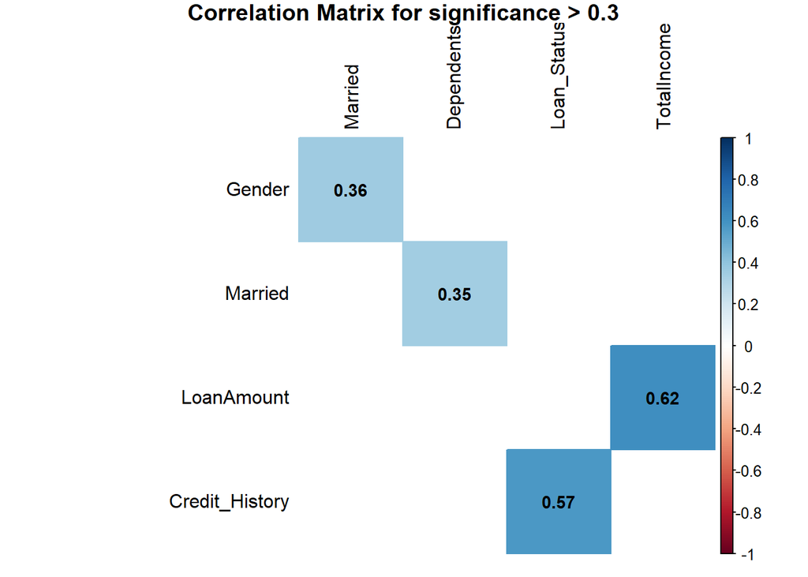

```r
#Utilize custom-built correlation matrix generation function
plot_corr_matrix(loan, 0.3)
```

From the correlation matrix we can extend that:

- `Credit_History` is our strongest predictor / strongly correlated with `Loan_Status`, and
- `Gender` and `Married`, `Married` and `Dependents`, `LoanAmount` and `TotalIncome` appear to be correlated with one another and indicative that multicollinearity may be a concern for our data.

We varied the threshold value for our correlation matrix and found that, aside from `Credit_History`, our other independent variables were relatively poor predictors of `Loan_Status`, making it worth exploring variable importance:

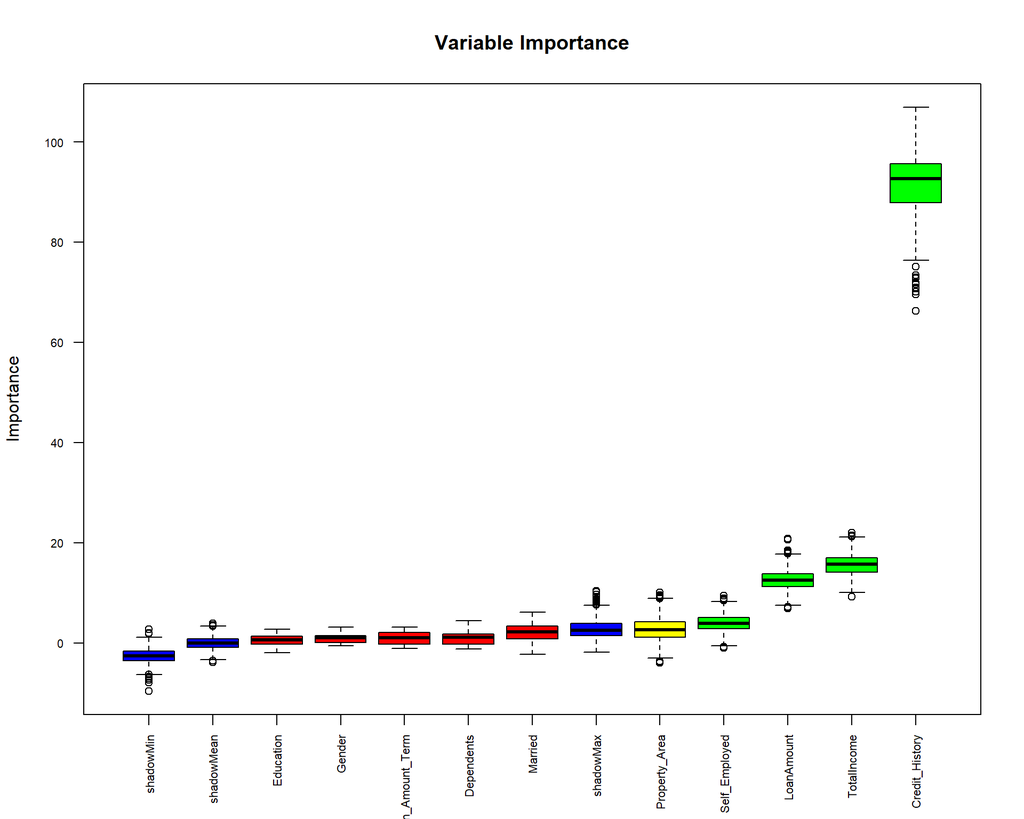

```r
#NOTE: COMMENTED OUT BELOW DUE TO LONG COMPILATION TIME. UNCOMMENT BEFORE FINAL SUBMISSION.

# Perform Boruta search
boruta_output <- Boruta(Loan_Status ~ ., data=na.omit(loan), doTrace=0, maxRuns = 1000)
#Get significant variables including tentatives
boruta_signif <- getSelectedAttributes(boruta_output, withTentative = TRUE)
#print(boruta_signif)
# Plot variable importance
plot(boruta_output, cex.axis=.7, las=2, xlab="", main="Variable Importance")
```

Our utilization of the **Boruta** function for feature ranking and selection indicate that:

- `Credit_History`, `TotalIncome`, `LoanAmount`, and `Self_Employed` are strong predictors,
- `Property_Area` is a moderate predictor, and
- `Married`, `Loan_Amount_Term`, `Education`, `Gender`, and `Dependents` are all poor predictors.

With feature importance in mind, we drop the poor predictors from consideration. Dropping these variables also addresses concerns of applicant discrimination (ie. rejection based on `Gender`) and thus we address two concerns with this act of feature selection.

## Independent Variable Distributions

With our loan dataset properly subset, we proceed to observing the distributions of our independent variables. First we observe numeric distributions:

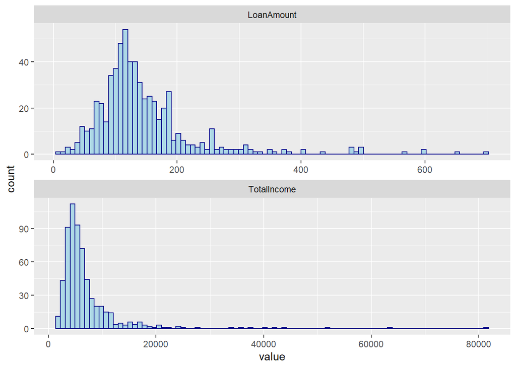

```r
#convert CreditHistory to type factor
loan$Credit_History <- factor(loan$Credit_History)
#levels(loan$Credit_History) #verify

#Numeric distributions
loan %>%
    keep(is.numeric) %>%
    gather() %>%
    ggplot(aes(value)) +
        facet_wrap(~ key, scales = "free", ncol=1) +
        geom_histogram(bins=90,color="darkblue", fill="lightblue")
```

From the above figures we observe that `LoanAmount` and `TotalIncome` appear to be right skewed normal and there are a number of noteworthy outliers for both distributions. From this, we note the importance of outlier-handling and scaling as critical steps in building our neural network model.

Next, we explore our categorical variables:

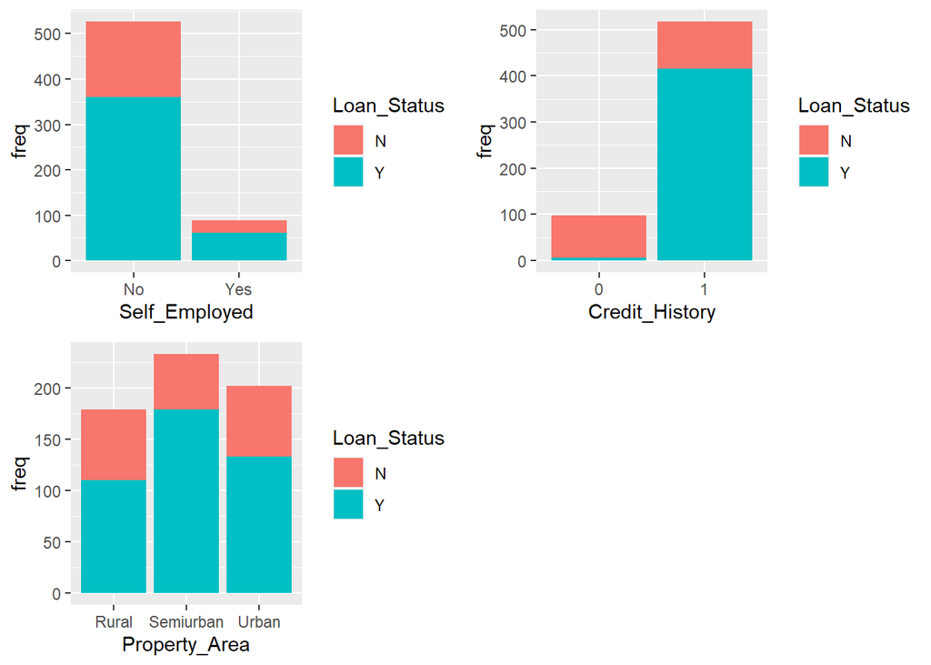

```r
#Categoric distributions
##Self_Employed
p1 <- loan %>% dplyr::select(1,5) %>% group_by(,Loan_Status) %>% count() %>%
    ggplot(aes(x=Self_Employed, y=freq, fill=Loan_Status)) +
        geom_bar(stat='identity', position="stack")
##Self_Employed
p2 <- loan %>% dplyr::select(3,5) %>% group_by(,Loan_Status) %>% count() %>%
    ggplot(aes(x=Credit_History, y=freq, fill=Loan_Status)) +
        geom_bar(stat='identity', position="stack")
##Property_Area
p3 <- loan %>% dplyr::select(4,5) %>% group_by(,Loan_Status) %>% count() %>%
    ggplot(aes(x=Property_Area, y=freq, fill=Loan_Status)) +
        geom_bar(stat='identity', position="stack")

grid.arrange(p1, p2, p3, nrow = 2, ncol = 2)
```

With a relatively thorough exploratory analysis under our belt, we move on to building our neural network model.

# Model Building

We’ll utilize the *holdout-validation method* for evaluating model performance. We train-test split our data using a 75:25 partition, build our model on the training set and then evaluate its performance on the test set.

## Neural Network #1 (nnet)

To start, we compute our “barrier value” and then partition our data based on this value, with 75% of our data going in the training set and 25% of our data going in the test set.

```r
set.seed(123) #replicability

bar <- floor(0.75 * nrow(loan)) #compute "barrier value"
partition <- sample(seq_len(nrow(loan)), size = bar) #sample based on barrier value

#Subset: train-test split based on partition value
train <- loan[partition, ]
test <- loan[-partition, ]

#print(dim(train)) #460 x 6
#print(dim(test)) #154 x 6
```

We set our training algorithm’s parameters and then train our model using the train() function with “nnet” passed in as the method and “scale” and “center” passed in so that numeric variables are standardized.

```r
set.seed(123) #replicability

#round(prop.table(table(train$Loan_Status)),3)   #Baseline accuracy Y: 0.685

#Training predictions
nnPred_train <-predict(nnet_model1, train)
#Training confusion matrix
table(train$Loan_Status, nnPred_train)
```

```
##    nnPred_train
##       N   Y
##   N  79  70
##   Y   4 307
```

```r
round((310+78)/nrow(train),3)
```

```
## [1] 0.843
```

```r
#Test predictions
nnPred_test <-predict(nnet_model1, test)
#Test confusion matrix
table(test$Loan_Status, nnPred_test)
```

```
##    nnPred_test
##       N   Y
##   N  23  20
##   Y   6 105
```

```r
round((106+21)/nrow(test),3)
```

```
## [1] 0.825
```

```r
#Performance statistics for later comparison
NN_Model_1 <- confusionMatrix(as.factor(nnPred_test), as.factor(test$Loan_Status))$byClass
acc1 <- confusionMatrix(as.factor(nnPred_test), as.factor(test$Loan_Status))$overall['Accuracy']
NN_Model_1 <- data.frame(NN_Model_1)
NN_Model_1 <- rbind("Accuracy" = acc1, NN_Model_1)
```

By merely applying a neural network model to our dataset, we see major improvements in predictive capability. Next, we see if we can take the model further. If we can improve model performance by handling outliers and creating features prior to feeding the model.

### Optimization Attempt

We explore the affects of outlier handling and feature creation on model performance to determine if either step improves our model.

We start by re-visiting the distribution of outliers via boxplot:

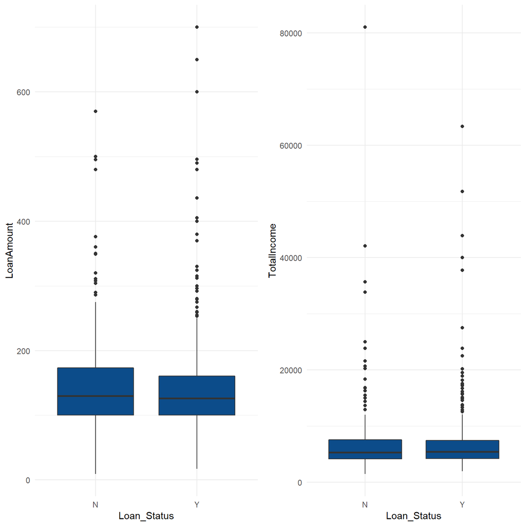

```r
set.seed(123) #replicability

#Observe the affect of outlier-handling on model performance (if any)

#Confirm the presence of influential observations
p4 <- ggplot(loan) +
  aes(x = Loan_Status, y = LoanAmount) +
  geom_boxplot(fill = "#0c4c8a") +
  theme_minimal()

p5 <- ggplot(loan) +
  aes(x = Loan_Status, y = TotalIncome) +
  geom_boxplot(fill = "#0c4c8a") +
  theme_minimal()

grid.arrange(p4, p5, nrow = 1, ncol = 2)
```

From above we can see that outliers appear to be a concern for our model.

**Outlier Handling**

To rectify the situation, we identify the outliers using the boxplot.stats() function, filter for corresponding observations, remove outliers from our dataset, and revisit model performance.

Outlier-handling led to a slight performance reduction for training and significant performance reduction for test data. As such we elected not to include outlier-handling as an optimization step. *Note: corresponding code has been included in the Appendix.*

We proceeded to observe the affect of feature creation on model performance.

**Feature Creation**

We wanted to see if adding certain combinations of features would improve our predictive accuracy. We tested the inclusion of variables for:

- self employed with high income,
- semiurban property with qualified credit history,
- not self employed with low loan amount, and
- low income with high loan amount.

The inclusion of these variables, and feature creation in general, *slightly* reduced the performance of our model and so we elected to exclude it as a modeling optimization step. *Note: corresponding code has been included in the Appendix.*

Being that each of our optimization attempts were fruitless, we next opted to explore two alternative approaches to neural networks to compare the predictive accuracy between approaches.

## Neural Network #2 (keras)

For our first “alternative” neural network approach, we consider the `keras` package and explore the characteristics of the model and means of optimizing the model:

- layers which are combined into a network (or model),
- input data and corresponding targets,
- the loss function which defines the feedback signal used for learning, and
- the optimizer which determines how learning proceeds.

We pre-process our data (converting variables to the proper type and changing categoric variable values from a character to a numeric-base) and then visualize the layers of our neural network:

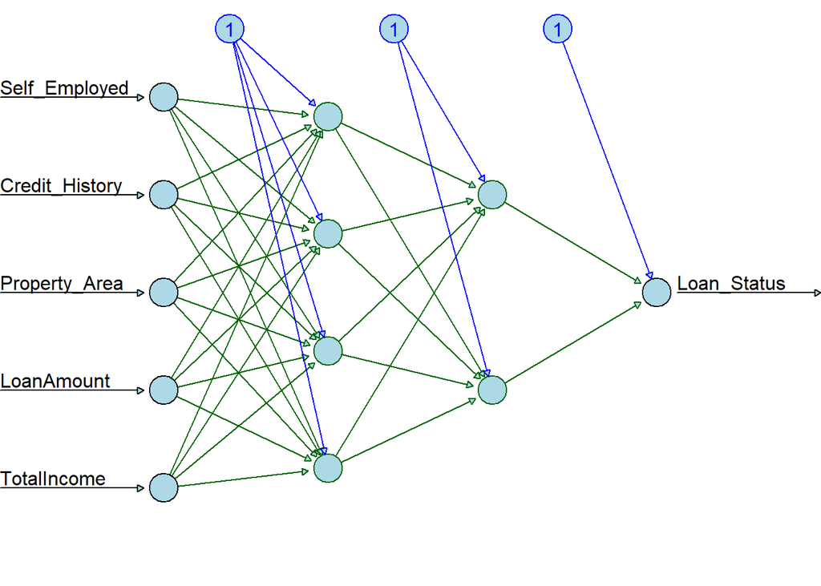

```r
set.seed(123) #replicability

#Preprocess data
loan_keras <-  loan_keras[, c(1, 3, 4, 2, 6, 5)]

# Convert Credit_History numeric type
loan_keras$Credit_History <- as.numeric(loan_keras$Credit_History)

# Change Variables values
loan_keras$Self_Employed <- ifelse(loan_keras$Self_Employed == "Yes", 1, 0)
loan_keras$Loan_Status <- ifelse(loan_keras$Loan_Status=="Y", 1, 0)

loan_keras$Property_Area <- case_when(
  loan_keras$Property_Area == "Semiurban" ~ 2,
  loan_keras$Property_Area == "Urban" ~ 1,
  loan_keras$Property_Area == "Rural" ~ 0,
)

#loan_keras <- loan_keras %>% mutate_if(is.factor, as.numeric) # convert factor to numeric

#Build initial keras NN model
n <- neuralnet(Loan_Status ~
                 Self_Employed +
                 Credit_History +
                 Property_Area +
                 LoanAmount +
                 TotalIncome,
               data = loan_keras,
               hidden = c(4,2),
               linear.output = F,
               lifesign = 'full',
               rep=1)

#Visualize our initial keras NN
plot(n,
     col.hidden = 'darkgreen',
     col.hidden.synapse = 'darkgreen',
     show.weights = F,
     information = F,
     fill = 'lightblue', rep = "best")
```

From the above visualization, we observe 5 input nodes, 2 hidden layers (1 with 4 neurons and 1 with 2 neurons), and 1 output node. As is the case with neural networks, all nodes are interconnected.

As a next step, we convert our data into matrix form, train-test split (using an 80/20 partition), and normalize (center and scale). We then build, compile, and train our model using the keras_model_sequential(), compile(), and fit() functions respectively.

We use the layer_dense() function to create the hidden layers for our network with “relu” (rectified linear unit) as our activation function, 5 inputs, 4 nodes in our 1st hidden layer, 2 nodes in our 2nd hidden layer, and 1 output node (as in our earlier visualization).

We compile our model using the following 3 arguments:

- **loss**: we elect “mse” (mean square error) which takes the sum of squared distances between target and prediction
- **optimizer**: default is rmsprop(lr stands for learning rate)
- **metrics**: list of metrics to be evaluated by the model. We elected accuracy.

Finally, we fit our model (with a validation proportion of 0.1 and 100 epochs) and visualize the model’s accuracy and loss for training and validation sets:

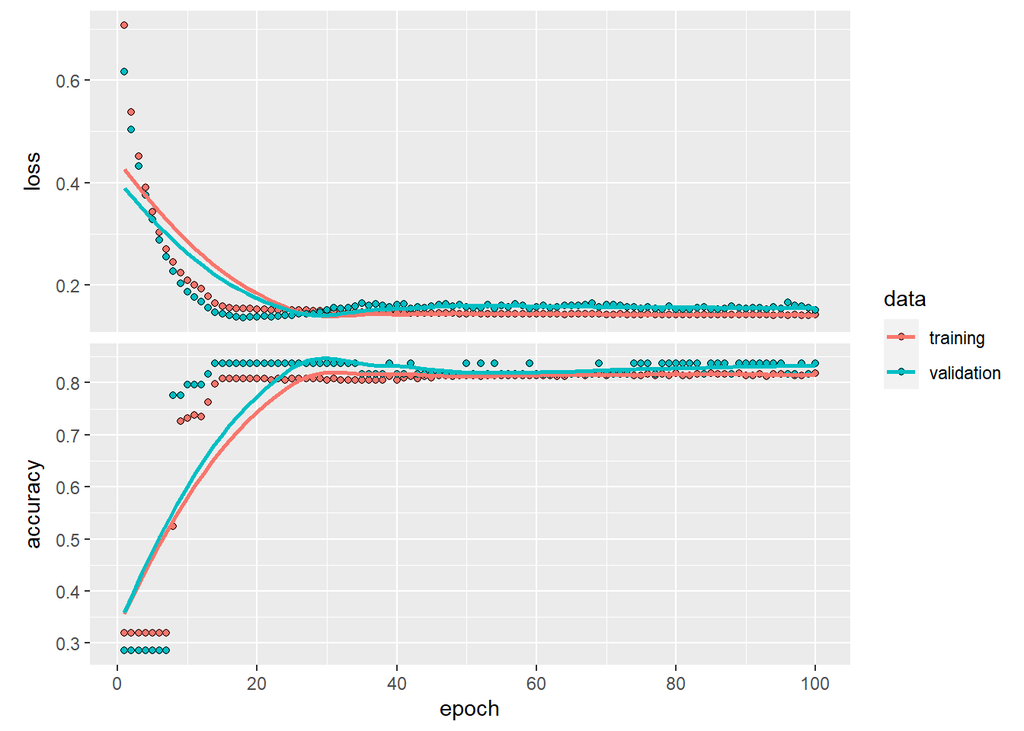

```r
set.seed(123) #replicability

#Build model
model_keras <- keras::keras_model_sequential()

model_keras %>%
         layer_dense(units = 4, activation = 'relu', input_shape = c(5)) %>%
         layer_dense(units = 2, activation = 'relu') %>%
         layer_dense(units = 1)

#Compile model
model_keras %>% compile(loss = 'mse',
                  optimizer = optimizer_rmsprop(lr= 0.005),
                  metrics = c("accuracy"))

#Train model
model_keras_train <- model_keras %>%
         fit(training_keras,
             trainingtarget,
             epochs = 100,
             validation_split = 0.1
             )

#Visualize
plot(model_keras_train)
```

The first graph is for loss whereas the second is for accuracy. There is little difference in loss for training vs. validation sets whereas when we consider accuracy, we see that training and validation accuracy start with a low accuracy (which makes sense) and then diverge shortly before the 10th epoch with validation settling ~0.85 and training settling ~0.8.

This appears to indicate that over-training is not a concern but we’ll explore further via evaluation metrics:

```r
set.seed(123) #replicability

#Evaluate model on training data
model_keras %>% evaluate(training_keras, trainingtarget)
```

```
##      loss  accuracy
## 0.1420742 0.8183674
```

```r
pred_keras_train <- model_keras %>% predict(training_keras)
#Evaluate model on test data
model_keras %>% evaluate(testing_keras, testingtarget)
```

```
##      loss  accuracy
## 0.1171924 0.8548387
```

```r
pred_keras_test <- model_keras %>% predict(testing_keras)
```

Our evaluation confirms that the keras model performs better on (unseen) test data.

We explore accuracy metrics for test data in confusion matrix form for further interpretation:

```r
set.seed(123) #replicability

# Confusion matrix and misclassification- test data
pred_keras_1 <- ifelse(pred_keras_test>0.5, 1, 0)


tab4 <- table(Predicted = pred_keras_1,
      Actual = testingtarget)
tab4
```

```
##          Actual
## Predicted  0  1
##         0 21  2
##         1 16 85
```

```r
sum(diag(tab4))/sum(tab4)
```

```
## [1] 0.8548387
```

As such, we’ll attempt to optimize this model.

### Optimization Attempt

We revisit our model with varied neurons / layer_dropout.

Increasing the number of neurons may improve model performance but that is not always the case and so we specify our “rate” as 0.4, re-specify our validation set as 0.2, and revisit our visualization and evaluation metrics to observe the effect:

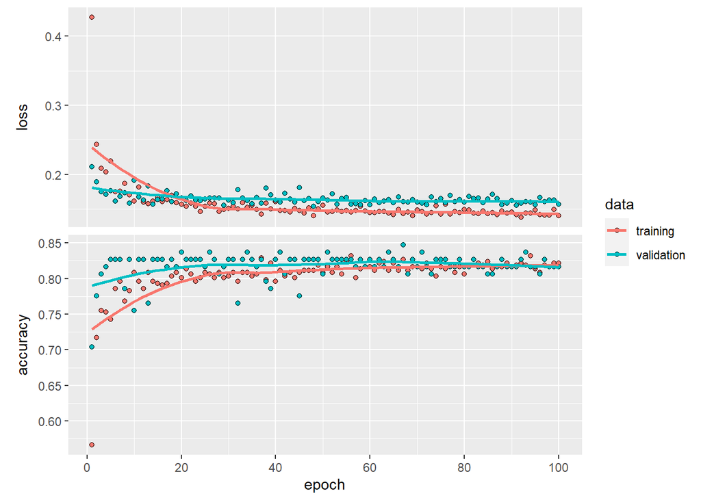

```r
set.seed(123) #replicability

#Create model2
model_keras_2 <- keras_model_sequential()
model_keras_2 %>%
         layer_dense(units = 100, activation = 'relu', input_shape = c(5)) %>%
         layer_dropout(rate = 0.4) %>%
         layer_dense(units = 1)

#Compile model2
model_keras_2 %>% compile(loss = 'mse',
                  optimizer = optimizer_rmsprop(lr= 0.005),
                  metrics = c("accuracy"))

#Fit model2
model_keras_train2 <- model_keras_2 %>%
         fit(training_keras,
             trainingtarget,
             epochs = 100,
             batch_size = 32,
             validation_split = 0.2
             )
#Visualize
plot(model_keras_train2)
```

Our loss visualization y axis covers a different range and it appears that our training loss is around ~0.15 while our validation loss stabilizes around ~0.17. When we consider that our training set was reduced in size this makes sense.

Our accuracy visualization’s y axis also covers a different range and and we observe that training and validation start with low accuracies, follow each other with validation slightly higher (0.825 vs. 0.81) and conclude with training accuracy and validation accuracy crossing paths ~75 epochs where then our training accuracy became higher.

We explore further via evaluation metrics and confusion matrix:

```r
set.seed(123) #replicability

#Evaluate model on training data
model_keras_2 %>% evaluate(training_keras, trainingtarget)
```

```
##      loss  accuracy
## 0.1385952 0.8224490
```

```r
pred_keras_train2 <- model_keras_2 %>% predict(training_keras) #loss: 0.1338, accuracy: 0.8390

#Evaluate model on test data
model_keras_2 %>% evaluate(testing_keras, testingtarget)
```

```
##      loss  accuracy
## 0.1210285 0.8709677
```

```r
pred_keras_test2 <- model_keras_2 %>% predict(testing_keras) #loss: 0.1413, accuracy: 0.8632

# Confusion matrix and misclassification
pred_keras_2 <- ifelse(pred_keras_test2>0.5, 1, 0)

tab5 <- table(Predicted = pred_keras_2,
      Actual = testingtarget)
tab5
```

```
##          Actual
## Predicted  0  1
##         0 24  3
##         1 13 84
```

```r
sum(diag(tab5))/sum(tab5)
```

```
## [1] 0.8709677
```

```r
#Performance statistics for later comparison
NN_Model_2 <- confusionMatrix(as.factor(pred_keras_2), as.factor(testingtarget))$byClass
acc1 <- confusionMatrix(as.factor(pred_keras_2), as.factor(testingtarget))$overall['Accuracy']
NN_Model_2 <- data.frame(NN_Model_2)
NN_Model_2 <- rbind("Accuracy" = acc1, NN_Model_2)
```

## Neural Network #3 (neural net)

For our second “alternative” neural network approach, we consider the `neuralnet` package and explore the characteristics of the model and means of optimizing the model.

We start by pre-processing our data:

- converting `Credit_History` to type numeric,
- re-assigning `Self_Employed` as Yes = 1, No = 0,
- re-assigning `Property_Area` as Semi-urban = 2, Urban = 1, and Rural = 0,
- re-assigning `Loan_Status` as Yes = 1, No = 0, and
- normalizing our variables to bring all data to a 0-to-1 scale via the following equation:

$$Transformed.Values = \frac{(Values - Min)}{(Max - Min)}$$
With our data in proper form (consistent, normalized variables), we train-test split using an 80/20 partition, train and visualize our model:

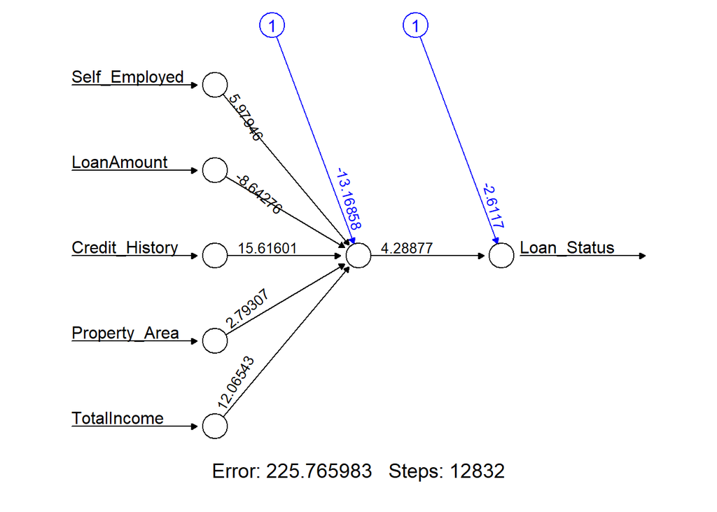

```r
set.seed(123) #replicability

# Convert Credit_History numeric type
loan_nn$Credit_History <- as.numeric(loan_nn$Credit_History)

# Change Variables values
loan_nn$Self_Employed <- ifelse(loan_nn$Self_Employed == "Yes", 1, 0)
loan_nn$Loan_Status <- ifelse(loan_nn$Loan_Status=="Y", 1, 0)

loan_nn$Property_Area <- case_when(
  loan_nn$Property_Area == "Semiurban" ~ 2,
  loan_nn$Property_Area == "Urban" ~ 1,
  loan_nn$Property_Area == "Rural" ~ 0,
)

# Min-Max Normalization
loan_nn$Self_Employed <- (loan_nn$Self_Employed - min(loan_nn$Self_Employed))/(max(loan_nn$Self_Employed) - min(loan_nn$Self_Employed))
loan_nn$LoanAmount <- (loan_nn$LoanAmount - min(loan_nn$LoanAmount))/(max(loan_nn$LoanAmount) - min(loan_nn$LoanAmount))
loan_nn$Credit_History <- (loan_nn$Credit_History - min(loan_nn$Credit_History))/(max(loan_nn$Credit_History)-min(loan_nn$Credit_History))
loan_nn$Property_Area <- (loan_nn$Property_Area - min(loan_nn$Property_Area))/(max(loan_nn$Property_Area)-min(loan_nn$Property_Area))
loan_nn$TotalIncome <- (loan_nn$TotalIncome - min(loan_nn$TotalIncome))/(max(loan_nn$TotalIncome)-min(loan_nn$TotalIncome))

# Train-test split
ind <- sample(2, nrow(loan_nn), replace = TRUE, prob = c(0.8, 0.2))
training_nn <- loan_nn[ind==1,]
testing_nn <- loan_nn[ind==2,]

#Train model
n1 <- neuralnet(Loan_Status ~ Self_Employed + LoanAmount + Credit_History + Property_Area + TotalIncome,
               data = training_nn,
               hidden = 1,
               err.fct = "ce",
               linear.output = FALSE
               )

#Visualize model
plot(n1, rep = "best")
```

The plot of our neural network above shows 5 input nodes, 1 hidden layer with 1 node, and 1 output node. The simplest neural network we’ve visited thus far.

After this point, we verified the predictive accuracy of our model via node output calculations with sigmoid activation function. *Note: corresponding code has been included in the Appendix.*

We then proceed to attempt to optimize our neuralnet model via feature selection.

### Optimization Attempt

Feature selection is used to select the most important features in a set. It’s a balancing act of selecting the fewest featuers that provide the greatest representative capability of the data and thus the strongest predictive accuracy.

We utilized forward feature selection, starting with no features and adding them back in one-by-one to find the strongest combination. During our exploratory data analysis, we found that `Credit_History` was the most important feature, so we began with this feature and tested combinations with other features until we arrived at:

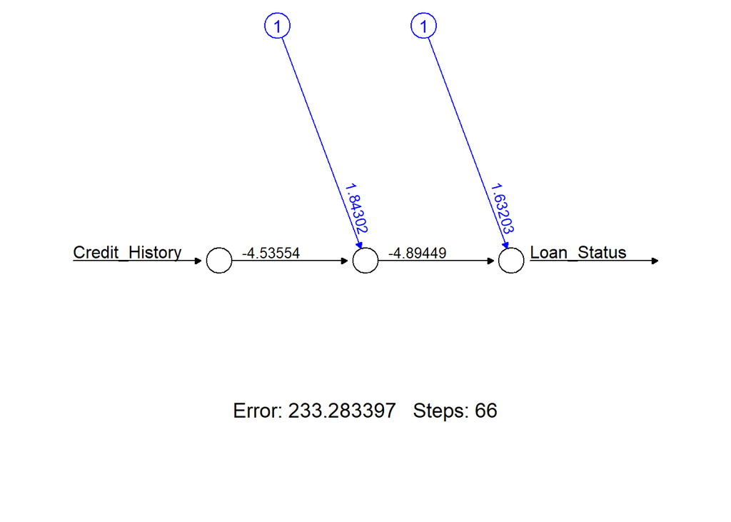

```r
set.seed(123)

#Adding other variables did not help model performance:
#Credit_History + Property_Area (0.871 test)
#Credit_History + TotalIncome (0.871 test)
#Credit_History + LoanAmount (0.871 test)
#Credit_History + SelfEmployed (0.871 test)

n2 <- neuralnet(Loan_Status ~ Credit_History,
               data = training_nn,
               hidden = 1,
               err.fct = "ce",
               linear.output = FALSE
               )

plot(n2, rep = 'best')
```

An even simpler model than that we had visited before: 1 input node, 1 hidden layer with 1 node, and 1 output node. From this we can derive that our strongest factor, `Credit_History` provides enough signal to accurately predict `Loan_Status`.

We then evaluate our model’s performance on training vs. test data and visit the corresponding confusion matrix:

```r
# Confusion Matrix & Misclassification Error - training data
output <- compute(n2, training_nn[,-5])
p1 <- output$net.result
pred1 <- ifelse(p1>0.5, 1, 0)
tab1 <- table(Prediction =  pred1, Actuals = training_nn$Loan_Status)
#tab1
paste0("Misclassification Error of training data: ", round(100 - sum(diag(tab1))/sum(tab1)*100,2))
```

```
## [1] "Misclassification Error of training data: 18.98"
```

```r
paste0("Accuracy of training data: ", round(sum(diag(tab1))/sum(tab1) * 100,2))
```

```
## [1] "Accuracy of training data: 81.02"
```

```r
# Confusion Matrix & Misclassification Error - testing data
output <- compute(n2, testing_nn[,-5])
p2 <- output$net.result
pred2 <- ifelse(p2>0.5, 1, 0)
tab2 <- table(Prediction = pred2, Actual = testing_nn$Loan_Status)
tab2
```

```
##           Actual
## Prediction  0  1
##          0 23  2
##          1 14 85
```

```r
paste0("Misclassification Error of testing data: ", round(100 - sum(diag(tab2))/sum(tab2)*100,2))
```

```
## [1] "Misclassification Error of testing data: 12.9"
```

```r
paste0("Accuracy of testing data: ", round(sum(diag(tab2))/sum(tab2)*100,2))
```

```
## [1] "Accuracy of testing data: 87.1"
```

```r
#Performance statistics for later comparison
NN_Model_3 <- confusionMatrix(as.factor(pred2), as.factor(testing_nn$Loan_Status))$byClass
acc1 <- confusionMatrix(as.factor(pred2), as.factor(testing_nn$Loan_Status))$overall['Accuracy']
NN_Model_3 <- data.frame(NN_Model_3)
NN_Model_3 <- rbind("Accuracy" = acc1, NN_Model_3)
```

From above, we observe our misclassification error and accuracy for test and training data. It appears that this model has performed as well as the prior model and, if we consider model simplicity as well, may be the strongest.

## NN Model Evaluation

Next, we re-visit the performance of all of our neural network models to determine which approach produced the strongest model.

We pull all models into a dataframe and output there performance metrics side-by-side:

```r
#Tabular view of model performance:
tabularview <- data.frame(NN_Model_1, NN_Model_2, NN_Model_3)
tabularview %>%  kableExtra::kbl() %>% kable_styling(bootstrap_options = c("striped", "hover", "condensed", "responsive"),latex_options="scale_down")
```

|  | NN_Model_1 | NN_Model_2 | NN_Model_3 |
| --- | --- | --- | --- |
| Accuracy | 0.8311688 | 0.8709677 | 0.8709677 |
| Sensitivity | 0.5348837 | 0.6486486 | 0.6216216 |
| Specificity | 0.9459459 | 0.9655172 | 0.9770115 |
| Pos Pred Value | 0.7931034 | 0.8888889 | 0.9200000 |
| Neg Pred Value | 0.8400000 | 0.8659794 | 0.8585859 |
| Precision | 0.7931034 | 0.8888889 | 0.9200000 |
| Recall | 0.5348837 | 0.6486486 | 0.6216216 |
| F1 | 0.6388889 | 0.7500000 | 0.7419355 |
| Prevalence | 0.2792208 | 0.2983871 | 0.2983871 |
| Detection Rate | 0.1493506 | 0.1935484 | 0.1854839 |
| Detection Prevalence | 0.1883117 | 0.2177419 | 0.2016129 |
| Balanced Accuracy | 0.7404148 | 0.8070829 | 0.7993166 |

We see that `NN_Model_2` and `NN_Model_3` compare closely for numerous metrics. Being that we’re dealing with an unbalanced set (more approvals predicted than rejections), we use the `Balanced Accuracy` metric as our determining factor and see that `NN_Model_2` (keras) is our strongest.

Later, we’ll provide an in-depth interpretation of this model’s statistics vs. those of our alternative classification approaches.

# Alternative Classification Approaches

Later, we’ll revisit pertinent statistics for our neural network models, but first we’ll explore the efficacy of alternatives to a neural network approach to compare and contrast methods. Being that the focus of this project was on neural networks, the section that follows provides a high level overview of each alternative approach (with corresponding code in the Appendix), output statistics near the conclusion, and a more thorough analysis of output statistics in our Model Comparison section.

## Decision Tree

Decision trees build classification or regression models in the form of a tree structure. Datasets are broken into smaller and smaller subsets along chosen parameters, as the associated decision tree is developed. The result is a tree with nodes and branches. Nodes denote a split point based on the attribute in question while branches denote the corresponding outcome. We start at a “root node”, terminate at “leaf nodes”, and use corresponding lead nodes to provide proportions regarding resulting class labels.

During EDA, we’d specified our most important features. We explored these features further (in tabular form), re-confirmed `Credit_History` as our most important feature and retained all remaining features for the simple fact that tree algorithms are immune to multicollinearity.

We used cross-validation, alternating between training and test data to increase the precision of our error estimation while determining the optimal tree depth and tuning complexity arguments.

We found that a depth of 2 and a cp value of 0.03 provided the highest corresponding accuracy and so we proceeded to finalize our model with optimal input parameters:

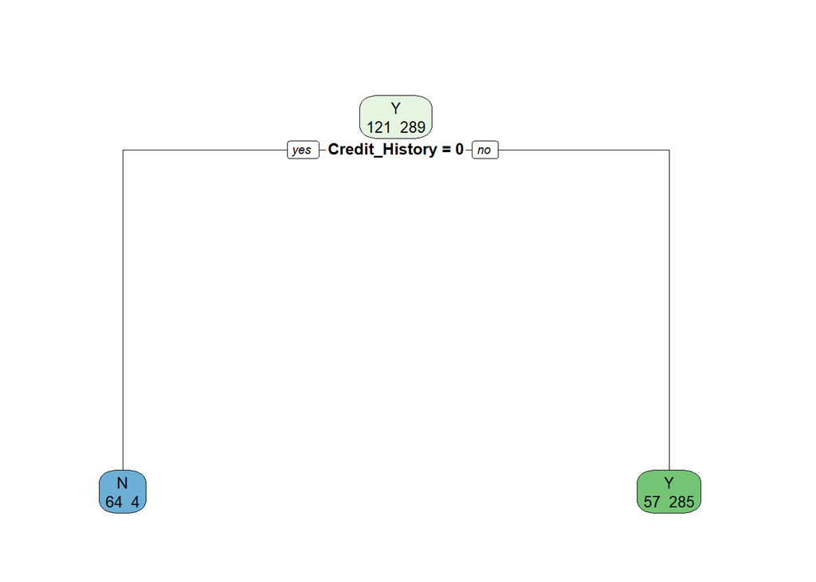

```r
tree_mod_final <- rpart(Loan_Status ~ ., data = train_data, method="class",
                  control = rpart.control(minsplit = 2,
                                          minbucket =  2,
                                          cp = 0.03,
                                          maxdepth = 2))

rpart.plot(tree_mod_final, extra=1, cex=0.8)
```

The tree appears to confirm our earlier findings regarding `Credit_History` and so we proceed to review its test data performance via confusion matrix and corresponding accuracy:

```r
loanPred <- predict(tree_mod_final, test_data, type = "class")

tab_dt <- table(Predicted = loanPred, Actual = test_data$Loan_Status)

tab_dt
```

```
##          Actual
## Predicted   N   Y
##         N  26   3
##         Y  45 130
```

```r
paste0("Accuracy : ", round(sum(diag(tab_dt))/sum(tab_dt) * 100,2))
```

```
## [1] "Accuracy : 76.47"
```

We find that our optimal decision tree model has an accuracy of 76.5% on test data with a total of 48 misclassifications. The model precisely predicts approval while simultaneously mispredicting loan rejection at an overwhelming rate. This may be because of the model’s dependence on `Credit_History` and that variable’s strength in predicting approval and weakness in predicting rejection. *We’ll revisit corresponding statistics in the Overall Model Comparison section.*

## Random Forest

As the next natural progression from decision trees, we move on to modeling via random forest (a collection of trees).

Random forests are one the most popular machine learning algorithms. They can be used for classification or regression, deal with a large number of features, and generally are so successful because they provide a good predictive performance, low incidence of over-fitting, and easy interpret-ability.

We train-test split our dataset using an 80/20 split, we then used the `randomforest` package to explore a simple random forest (using all variables as predictors), we visited a plot of the class error rates, observed that as the number of trees increases the error rates stabilize and the Y classifier approaches 0, we then visited the corresponding confusion matrix for test data:

```r
set.seed(66)

pred_rf <- predict(model_rf, test_data_rf, type="class")
tab_rf <- table(Predicted = pred_rf, Actual = test_data_rf$Loan_Status)
tab_rf
```

```
##          Actual
## Predicted   N   Y
##         N  44   4
##         Y  22 136
```

```r
pred_rf <- as.factor(pred_rf)
test_data_rf$Loan_Status <- as.factor(test_data_rf$Loan_Status)
paste0("Accuracy : ",round(sum(diag(tab_rf))/sum(tab_rf)*100,2))
```

```
## [1] "Accuracy : 87.38"
```

```r
RF_Model_1 <- confusionMatrix(pred_rf, test_data_rf$Loan_Status)$byClass
acc1 <- confusionMatrix(pred_rf, test_data_rf$Loan_Status)$overall['Accuracy']
RF_Model_1 <- data.frame(RF_Model_1)
RF_Model_1 <- rbind("Accuracy" = acc1, RF_Model_1)
```

We observed an accuracy of ~87.4% and proceeded to attempt to optimize the model further.

We plotted feature importance to observe those that most vs. least affected the model’s predictive capability, we tuned the number of trees to minimize the error rate, created a second model (`RF_Model_2`) observed that the accuracy had actually decreased by ~1% on test data.

We then tuned on `mtry` and `ntree`, created another model (`RF_Model_3`), and observed that its accuracy for test data was 86.89% and **thus our first model (`RF_Model_1`), the model without any optimization attempts, appears to have been our strongest.**

We visit a tabular output for the performance metrics of `RF_Model_1` vs `RF_Model_2` and `RF_Model_3` and confirm that `RF_Model_1` was the strongest. We only visited the tabular output for our random forest models because they were *by far* the strongest performing alternative approaches to classification and we had to decipher between the models as to which was the strongest. *The corresponding comparison table’s code is available in the Appendix.*

## kNN

The KNN algorithm hinges on the idea that similar data will be near one another. When applying KNN, the distance between data points are used to classify data. Those nearer one another are “batched” together. The amount of batches we see and the distance between points is determined by the k value we select:

- Smaller k –> fewer batches and larger distance between “like” points.
- Larger k –> more batches and smaller distance between “like” points.

Due to the simplicity of calculations involved and ease of interpretability of the result, KNN is a popular classifier. For our purposes, we’re going to apply the K-nearest neighbor algorithm to the loan dataset to predict the `Loan_Status` variable.

We convert categorical variables to numerical, apply standard scaling to bring each variable in the dataset to have a mean of 0 and standard deviation of 1 (using $z_i= \frac {x_i−\bar x}{s_x}$)m and then train-test split our dataset.

We explore model performance using actual and scaled data, vary k from a range of 1 to 100 to determine the optimal value, select our final model based on which was more accurate (scaled was more accurate than unscaled)

```r
set.seed(26) #ensure reproducibility

#Select optimal k for SCALED data
acc_sc <- which.max(valid_acc_sc)
#acc_sc

#Confusion matrix and accuracy for scaled data model with k = 10
train_pred <- knn(training_knn, training_knn, trainingtarget_knn, k=acc_sc)
train_acc <- mean(train_pred == trainingtarget_knn)

valid_pred <- knn(training_knn, testing_knn, trainingtarget_knn, k=acc_sc)
valid_acc <- mean(valid_pred == testingtarget_knn)

cat('Training Accuracy:   ', train_acc, '\n',
    'Validation Accuracy: ', valid_acc, sep='')
```

```
## Training Accuracy:   0.8298755
## Validation Accuracy: 0.8333333
```

```r
tab_knn_sc <-  table(Predicted = valid_pred, Actual = testingtarget_knn)
tab_knn_sc
```

```
##          Actual
## Predicted  0  1
##         0 17  6
##         1 16 93
```

From above we observe a relatively strong prediction rate for a approvals and a near 50/50 split when it comes to predicting rejections which is quite low. It would appear that this is a sub-optimal model, and it may be because our rejections require more nuanced detection methods than grouping based on its nearest neighbors.

## Gradient Boosting

Boosting is a method for creating an ensemble, or a combination of machine learning models. *Gradient* boosting relies on the belief that the best possible next model, when combined with prior models, reduces how often we misclassify our data.

It’s heralded as one of the most powerful techniques for building predictive models and offers numerous options for implementation. We’ll make use of the **XGBoost** (eXtreme Gradient Boosting) distributed gradient library due to its promise of flexibility, portability, and efficiency.

For our purposes, we’re dealing with a categorical dependent variable, and will build a Gradient Boosting model from the loan approval dataset to provide `Loan_Status` predictions (ie. Approve or Reject).

```r
#prediction and confusion matrix from TRAIN data
p_train <- predict(GB_model, newdata = train_matrix)
pred_train <- matrix(p_train, nrow = nc, ncol = length(p_train)/nc) %>%
    t() %>% #matrix transpose
    data.frame() %>%
    mutate(label = train_label, max_prob = max.col(.,"last")-1)

tab_train <- table(Prediction = pred_train$max_prob, Actual = pred_train$label)
print(tab_train)
```

```
##           Actual
## Prediction   0   1
##          0 108   2
##          1  49 298
```

```r
print(paste('Misclassification Error with Train data', round(1 - sum(diag(tab_train))/sum(tab_train),3))) #0.112
```

```
## [1] "Misclassification Error with Train data 0.112"
```

```r
#prediction and confusion matrix from TEST data
p_test <- predict(GB_model, newdata = test_matrix)
pred_test <- matrix(p_test, nrow = nc, ncol = length(p_test)/nc) %>%
    t() %>% #matrix transpose
    data.frame() %>%
    mutate(label = test_label, max_prob = max.col(.,"last")-1)

tab_test <- table(Prediction = pred_test$max_prob, Actual = pred_test$label)
print(tab_test)
```

```
##           Actual
## Prediction   0   1
##          0  15   8
##          1  20 114
```

```r
print(paste('Misclassification Error with Test data', round(1 - sum(diag(tab_test))/sum(tab_test),3))) #0.178
```

```
## [1] "Misclassification Error with Test data 0.178"
```

```r
#feature importance
imp <- xgb.importance(colnames(train_matrix), model=GB_model)
print(imp) #higher Gain means higher feature importance
```

```
##           Feature       Gain      Cover  Frequency
## 1: Credit_History 0.52509792 0.18382990 0.04666667
## 2:    TotalIncome 0.25538857 0.43982782 0.46833333
## 3:     LoanAmount 0.16711178 0.24865180 0.38666667
## 4:  Property_Area 0.03417599 0.11209544 0.06166667
## 5:  Self_Employed 0.01822575 0.01559505 0.03666667
```

From above we note 0.112 and 0.178 misclassification error rates (the opposite of accuracy) on training and test data respectively. This a strong performance although not quite as strong as the RF models we’d explored earlier and so we attempt to optimize.

From our feature importance scores, we observed that `Credit_History`, `TotalIncome`, and `LoanAmount` had the highest `Gain` scores and so we omitted all other features in our second model. After adapting our matrices, building our model, and optimizing input parameters (ie. `nrounds`), we found that selecting features *slightly reduced* our model accuracy and so our first model outperformed our second.

With a rather in-depth exploration of alternative models under our belt, we proceed to compare the strongest performing of our models: random forest and neural network.

# Overall Model Comparison

We put our strongest Random Forest and Neural Network models side-by-side to interpret their common classification metrics and determine which has the greatest predictive accuracy.

We consider the following classification metrics in consulting each model’s Confusion Matrix:

- **Accuracy** : $\frac{TP+TN}{TP + FP + TN + FN}$
- **Sensitivity (Recall)** : true positive rate. $\frac{TP}{TP + FN}$
- **Specificity**: true negative rate. $\frac{TN}{TN + FP}$
- **Pos Pred Value (Precision)** : probability that predicted positive is truly positive. $\frac{TP}{TP + FP}$
- **Neg Pred Value**: probability that predicted negative is truly negative. $\frac{TN}{(TN + FN)}$
- **F1**: harmonic mean of model’s precision and recall. $\frac{2 * (Precision * Recall)}{Precision + Recall}$
- **Prevalence**: truly positive observations as proportion of total number of observations. $\frac{TP + FN}{TP + FP + FN + TN}$
- **Detection Rate**: true positives detected as proportion of entire total population. $\frac{TP}{TP + FP + FN + TN}$
- **Detection Prevalence**: predicted positive events over total number of predictions. $\frac{TP + FP}{TP + FP + FN + TN}$
- **Balanced Accuracy**: measure of model’s that is especially useful when classes are imbalanced. $\frac{Sensitivity + Specificity}{2}$

These models are all applied to the test data set and make use of the **confusionMatrix** function from the caret library. We present the corresponding common classification metrics as a kable table to glean more insight regarding the relative strength of each model’s performance:

```r
#Tabular view of our 2 strongest models:
tabularview <- data.frame(RF_Model_1, NN_Model_2)
tabularview %>%  kableExtra::kbl() %>% kable_styling(bootstrap_options = c("striped", "hover", "condensed", "responsive"),latex_options="scale_down")
```

|  | RF_Model_1 | NN_Model_2 |
| --- | --- | --- |
| Accuracy | 0.8737864 | 0.8709677 |
| Sensitivity | 0.6666667 | 0.6486486 |
| Specificity | 0.9714286 | 0.9655172 |
| Pos Pred Value | 0.9166667 | 0.8888889 |
| Neg Pred Value | 0.8607595 | 0.8659794 |
| Precision | 0.9166667 | 0.8888889 |
| Recall | 0.6666667 | 0.6486486 |
| F1 | 0.7719298 | 0.7500000 |
| Prevalence | 0.3203883 | 0.2983871 |
| Detection Rate | 0.2135922 | 0.1935484 |
| Detection Prevalence | 0.2330097 | 0.2177419 |
| Balanced Accuracy | 0.8190476 | 0.8070829 |

# Conclusion

We explored `nnet`, `keras` and `neuralnet` as neural network approaches. Our assumption was that the top performing neural network model would be our strongest model. This assumption was based in our hearing a lot about the advantages and applications of deep learning models. In particular, we thought that backpropagation as well as the ability to adapt hidden layers to further improve performance would lead to a major performance advantage.

Our strongest neural network model outperformed all alternative models by a significant margin … aside from random forests. The accuracies and balanced accuracies were quite close but our strongest random forest model edged our strongest neural network model by a slight margin.

This surprised our entire group considering that we’d applied random forest, decision tree, and gradient boosting models in a past assignment to the same dataset and had the random forest model perform the worst and the gradient boosting model perform the best.

We explored and prepared the data in a different manner this time though.

We selected only pertinent variables and we combined our incomes to create a `TotalIncome` variable. The data preparation we’d done as well as our use of set seeds and various arguments for the methods we used within each model likely played a role. With just a couple of slight model or data preparation changes we may have seen a different outcome. And this was our largest lesson learned.

When an approach is lauded, mystical, and popular, that doesn’t necessarily mean that its applicable in every situation. There is no “one size fits all” in Data Science. In this case the Random Forest model may have performed better because of the data at hand, the way we applied our methods, or because it was simply most advantageous in this particular situation. If we were to apply each model with different set seeds, the accuracies may have varied and we may have come to a different conclusion, and that’s the beauty of Data Science.

There’s much to be learned.

# Appendix with Code

```r
#Standardize chunk-knitting
knitr::opts_chunk$set(echo = TRUE, message = FALSE, warning = FALSE)

set.seed(123) #ensure reproducibility

#Load relevant libraries
library(tidyverse)
library(caret)
library(ggplot2)
library(MASS)
library(dplyr)
library(kableExtra)
library(plyr) #revalue 'Dependent'
library(mice) #pmm imputation
library(corrplot) #correlation matrix
library(Boruta) #Utilize Boruta for feature ranking and selection
library(gridExtra) #output plots via grid.arrange
library(car) #outlier handling
library(caTools)
library(keras) #NN approach 2
library(neuralnet) #NN approach 3
require(reshape2) # small multiple density plot
library(class) # kNN
library(rpart) # DT
library(rpart.plot)# DT
library(data.table)
library(randomForest) # RF
library(e1071) #skewness
library(gbm)
library(xgboost)      # a faster implementation of gbm
library(Matrix)

#Utilize customized functions
plot_corr_matrix <- function(dataframe, significance_threshold){
  title <- paste0('Correlation Matrix for significance > ',
                  significance_threshold)

  df_cor <- dataframe %>% mutate_if(is.character, as.factor)

  df_cor <- df_cor %>% mutate_if(is.factor, as.numeric)
  #run a correlation and drop the insignificant ones
  corr <- cor(df_cor)
  #prepare to drop duplicates and correlations of 1
  corr[lower.tri(corr,diag=TRUE)] <- NA
  #drop perfect correlations
  corr[corr == 1] <- NA
  #turn into a 3-column table
  corr <- as.data.frame(as.table(corr))
  #remove the NA values from above
  corr <- na.omit(corr)
  #select significant values
  corr <- subset(corr, abs(Freq) > significance_threshold)
  #sort by highest correlation
  corr <- corr[order(-abs(corr$Freq)),]
  #print table
  # print(corr)
  #turn corr back into matrix in order to plot with corrplot
  mtx_corr <- reshape2::acast(corr, Var1~Var2, value.var="Freq")

  #plot correlations visually
  corrplot(mtx_corr,
           title=title,
           mar=c(0,0,1,0),
           method='color',
           tl.col="black",
           na.label= " ",
           addCoef.col = 'black',
           number.cex = .9)
}

download.file(
    url='https://1.cms.s81c.com/sites/default/files/2021-01-06/ICLH_Diagram_Batch_01_03-DeepNeuralNetwork-WHITEBG.png',
    destfile='image1.jpg',
    mode='wb')
knitr::include_graphics(path='image1.jpg')

#Load in data
loan <- read.csv("https://raw.githubusercontent.com/SubhalaxmiRout002/Data-622-Group-5/main/Final_Project/Loan_approval.csv", stringsAsFactors = TRUE)

loan[loan==""] <- NA #replace empty strings with NAs
#head(loan) #verify 1st 6 observations

#Light EDA
glimpse(loan)
summary(loan)

#Pre-process dataset for easier interpretation
loan <- subset(loan, select = -c(1) ) #drop Loan_ID from consideration
loan$TotalIncome <- loan$CoapplicantIncome + loan$ApplicantIncome #create TotalIncome variable
loan <- subset(loan, select = -c(6,7) ) #drop CoapplicantIncome and ApplicantIncome
loan$Dependents <- revalue(loan$Dependents, c("3+"="3")) #relabel Dependents "3+" value as "3"

#Visualize NA counts
colSums(is.na(loan))

#Handle NAs: apply predictive mean matching to loan data
loan <- mice(loan, m = 1, method = "pmm", seed = 500)
loan <- mice::complete(loan, 1)

#verify absence of NA values in the dataset
colSums(is.na(loan))

#Utilize custom-built correlation matrix generation function
plot_corr_matrix(loan, 0.3)

#NOTE: COMMENTED OUT BELOW DUE TO LONG COMPILATION TIME. UNCOMMENT BEFORE FINAL SUBMISSION.

# Perform Boruta search
boruta_output <- Boruta(Loan_Status ~ ., data=na.omit(loan), doTrace=0, maxRuns = 1000)
#Get significant variables including tentatives
boruta_signif <- getSelectedAttributes(boruta_output, withTentative = TRUE)
#print(boruta_signif)
# Plot variable importance
plot(boruta_output, cex.axis=.7, las=2, xlab="", main="Variable Importance")

#Subset data based on predictor strength
loan <- subset(loan, select = -c(1, 2, 3, 4, 7) ) #drop poor predictors
#head(loan) #verify


# created 5 datasets for LR, Neural nets, NN using keras, kNN, Decison Tree
loan_new2 <- loan
loan_nn <- loan
loan_keras <- loan
loan_knn <- loan
loan_dt <- loan
loan_rf <- loan
loan_GB <- loan

#convert CreditHistory to type factor
loan$Credit_History <- factor(loan$Credit_History)
#levels(loan$Credit_History) #verify

#Numeric distributions
loan %>%
    keep(is.numeric) %>%
    gather() %>%
    ggplot(aes(value)) +
        facet_wrap(~ key, scales = "free", ncol=1) +
        geom_histogram(bins=90,color="darkblue", fill="lightblue")

#Categoric distributions
##Self_Employed
p1 <- loan %>% dplyr::select(1,5) %>% group_by(,Loan_Status) %>% count() %>%
    ggplot(aes(x=Self_Employed, y=freq, fill=Loan_Status)) +
        geom_bar(stat='identity', position="stack")
##Self_Employed
p2 <- loan %>% dplyr::select(3,5) %>% group_by(,Loan_Status) %>% count() %>%
    ggplot(aes(x=Credit_History, y=freq, fill=Loan_Status)) +
        geom_bar(stat='identity', position="stack")
##Property_Area
p3 <- loan %>% dplyr::select(4,5) %>% group_by(,Loan_Status) %>% count() %>%
    ggplot(aes(x=Property_Area, y=freq, fill=Loan_Status)) +
        geom_bar(stat='identity', position="stack")

grid.arrange(p1, p2, p3, nrow = 2, ncol = 2)

set.seed(123) #replicability

bar <- floor(0.75 * nrow(loan)) #compute "barrier value"
partition <- sample(seq_len(nrow(loan)), size = bar) #sample based on barrier value

#Subset: train-test split based on partition value
train <- loan[partition, ]
test <- loan[-partition, ]

#print(dim(train)) #460 x 6
#print(dim(test)) #154 x 6

set.seed(123) #replicability

#Specify training algorithm parameters
train_params <- trainControl(method = "repeatedcv", number = 10, repeats=5)

#Train neural net model and standardize variables via preProcess method
nnet_model1 <- train(train[,-5], train$Loan_Status,
                 method = "nnet",
                 trControl= train_params,
                 preProcess=c("scale","center"),
                 na.action = na.omit
)

set.seed(123) #replicability

#round(prop.table(table(train$Loan_Status)),3)   #Baseline accuracy Y: 0.685
```

```r
#Training predictions
nnPred_train <-predict(nnet_model1, train)
#Training confusion matrix
table(train$Loan_Status, nnPred_train)
round((310+78)/nrow(train),3)

#Test predictions
nnPred_test <-predict(nnet_model1, test)
#Test confusion matrix
table(test$Loan_Status, nnPred_test)
round((106+21)/nrow(test),3)

#Performance statistics for later comparison
NN_Model_1 <- confusionMatrix(as.factor(nnPred_test), as.factor(test$Loan_Status))$byClass
acc1 <- confusionMatrix(as.factor(nnPred_test), as.factor(test$Loan_Status))$overall['Accuracy']
NN_Model_1 <- data.frame(NN_Model_1)
NN_Model_1 <- rbind("Accuracy" = acc1, NN_Model_1)

set.seed(123) #replicability

#Observe the affect of outlier-handling on model performance (if any)

#Confirm the presence of influential observations
p4 <- ggplot(loan) +
  aes(x = Loan_Status, y = LoanAmount) +
  geom_boxplot(fill = "#0c4c8a") +
  theme_minimal()

p5 <- ggplot(loan) +
  aes(x = Loan_Status, y = TotalIncome) +
  geom_boxplot(fill = "#0c4c8a") +
  theme_minimal()

grid.arrange(p4, p5, nrow = 1, ncol = 2)

set.seed(123) #replicability

#Identify outlier locations for LoanAmount, TotalIncome
out1 <- boxplot.stats(loan$LoanAmount)$out
outliers1 <- which(loan$LoanAmount %in% c(out1))

out2 <- boxplot.stats(loan$TotalIncome)$out
outliers2 <- which(loan$TotalIncome %in% c(out2))

outliers <- c(outliers1, outliers2) #merge lists
outliers <- unique(outliers) #remove repeat values

#Remove outliers
loan <- loan[-outliers,]

#Observe affect on model performance

bar <- floor(0.75 * nrow(loan)) #compute "barrier value"
partition2 <- sample(seq_len(nrow(loan)), size = bar) #sample based on barrier value

#Subset: train-test split based on partition value
train2 <- loan[partition2, ]
test2 <- loan[-partition2, ]

#Train neural net model and standardize variables via preProcess method
nnet_model2 <- train(train2[,-5], train2$Loan_Status,
                 method = "nnet",
                 trControl= train_params,
                 preProcess=c("scale","center"),
                 na.action = na.omit
)

#Training predictions
nnPred_train2 <-predict(nnet_model2, train2)
#Training confusion matrix
table(train2$Loan_Status, nnPred_train2)
round((282+63)/nrow(train2),3) #0.839

#Test predictions
nnPred_test2 <-predict(nnet_model2, test2)
#Test confusion matrix
table(test2$Loan_Status, nnPred_test2)
round((94+17)/nrow(test),3) #0.721

set.seed(123) #replicability

#Observe the affect of feature creation on model performance (if any)

#if self employed and income greater than
loan$hiINC_SE <- as.factor(ifelse(loan$TotalIncome >= 7522 & loan$Self_Employed == "Yes", 1, 0))

#if semiurban property and credit history 1
loan$SEMI_CH <- as.factor(ifelse(loan$Property_Area == "Semiurban" & loan$Credit_History == 1, 1, 0))

#if not self employed and loan amount below
loan$notSE_CH <- as.factor(ifelse(loan$Self_Employed == "No" & loan$LoanAmount <= 100.0, 1, 0))

#if income below and loan amount above
loan$loINC_hiAMT <- as.factor(ifelse(loan$TotalIncome <= 4166 & loan$LoanAmount >= 166.8, 1, 0))

#head(loan) #verify

set.seed(123) #replicability

bar <- floor(0.75 * nrow(loan)) #compute "barrier value"
partition2 <- sample(seq_len(nrow(loan)), size = bar) #sample based on barrier value

#Subset: train-test split based on partition value
train2 <- loan[partition2, ]
test2 <- loan[-partition2, ]

#Train neural net model and standardize variables via preProcess method
nnet_model2 <- train(train2[,-5], train2$Loan_Status,
                 method = "nnet",
                 trControl= train_params,
                 preProcess=c("scale","center"),
                 na.action = na.omit
)

#Training predictions
nnPred_train2 <-predict(nnet_model2, train2)
#Training confusion matrix
table(train2$Loan_Status, nnPred_train2)
round((282+63)/nrow(train2),3) #0.839 - LOWER

#Test predictions
nnPred_test2 <-predict(nnet_model2, test2)
#Test confusion matrix
table(test2$Loan_Status, nnPred_test2)
round((94+17)/nrow(test),3) #0.721 - LOWER

set.seed(123) #replicability

#Preprocess data
loan_keras <-  loan_keras[, c(1, 3, 4, 2, 6, 5)]

# Convert Credit_History numeric type
loan_keras$Credit_History <- as.numeric(loan_keras$Credit_History)

# Change Variables values
loan_keras$Self_Employed <- ifelse(loan_keras$Self_Employed == "Yes", 1, 0)
loan_keras$Loan_Status <- ifelse(loan_keras$Loan_Status=="Y", 1, 0)

loan_keras$Property_Area <- case_when(
  loan_keras$Property_Area == "Semiurban" ~ 2,
  loan_keras$Property_Area == "Urban" ~ 1,
  loan_keras$Property_Area == "Rural" ~ 0,
)

#loan_keras <- loan_keras %>% mutate_if(is.factor, as.numeric) # convert factor to numeric

#Build initial keras NN model
n <- neuralnet(Loan_Status ~
                 Self_Employed +
                 Credit_History +
                 Property_Area +
                 LoanAmount +
                 TotalIncome,
               data = loan_keras,
               hidden = c(4,2),
               linear.output = F,
               lifesign = 'full',
               rep=1)

#Visualize our initial keras NN
plot(n,
     col.hidden = 'darkgreen',
     col.hidden.synapse = 'darkgreen',
     show.weights = F,
     information = F,
     fill = 'lightblue', rep = "best")
set.seed(123) #replicability

# Matrix
loan_keras <- as.matrix(loan_keras)
dimnames(loan_keras) <- NULL

# Partition
ind <- sample(2, nrow(loan_keras), replace = T, prob = c(.8, .2))
training_keras <- loan_keras[ind==1,1:5]
testing_keras <- loan_keras[ind==2, 1:5]
trainingtarget <- loan_keras[ind==1, 6]
testingtarget <- loan_keras[ind==2, 6]

# Normalize
m <- colMeans(training_keras)
s <- apply(training_keras, 2, sd)
training_keras <- scale(training_keras, center = m, scale = s)
testing_keras <- scale(testing_keras, center = m, scale = s)

set.seed(123) #replicability

#Build model
model_keras <- keras::keras_model_sequential()

model_keras %>%
         layer_dense(units = 4, activation = 'relu', input_shape = c(5)) %>%
         layer_dense(units = 2, activation = 'relu') %>%
         layer_dense(units = 1)
```

```r
#Compile model
model_keras %>% compile(loss = 'mse',
                  optimizer = optimizer_rmsprop(lr= 0.005),
                  metrics = c("accuracy"))

#Train model
model_keras_train <- model_keras %>%
         fit(training_keras,
             trainingtarget,
             epochs = 100,
             validation_split = 0.1
             )

#Visualize
plot(model_keras_train)
set.seed(123) #replicability

#Evaluate model on training data
model_keras %>% evaluate(training_keras, trainingtarget)
pred_keras_train <- model_keras %>% predict(training_keras)
#Evaluate model on test data
model_keras %>% evaluate(testing_keras, testingtarget)
pred_keras_test <- model_keras %>% predict(testing_keras)
set.seed(123) #replicability

# Confusion matrix and misclassification- test data
pred_keras_1 <- ifelse(pred_keras_test>0.5, 1, 0)


tab4 <- table(Predicted = pred_keras_1,
      Actual = testingtarget)
tab4

sum(diag(tab4))/sum(tab4)
set.seed(123) #replicability

#Create model2
model_keras_2 <- keras_model_sequential()
model_keras_2 %>%
         layer_dense(units = 100, activation = 'relu', input_shape = c(5)) %>%
         layer_dropout(rate = 0.4) %>%
         layer_dense(units = 1)

#Compile model2
model_keras_2 %>% compile(loss = 'mse',
                  optimizer = optimizer_rmsprop(lr= 0.005),
                  metrics = c("accuracy"))

#Fit model2
model_keras_train2 <- model_keras_2 %>%
         fit(training_keras,
             trainingtarget,
             epochs = 100,
             batch_size = 32,
             validation_split = 0.2
             )
#Visualize
plot(model_keras_train2)

set.seed(123) #replicability

#Evaluate model on training data
model_keras_2 %>% evaluate(training_keras, trainingtarget)
pred_keras_train2 <- model_keras_2 %>% predict(training_keras) #loss: 0.1338, accuracy: 0.8390

#Evaluate model on test data
model_keras_2 %>% evaluate(testing_keras, testingtarget)
pred_keras_test2 <- model_keras_2 %>% predict(testing_keras) #loss: 0.1413, accuracy: 0.8632

# Confusion matrix and misclassification
pred_keras_2 <- ifelse(pred_keras_test2>0.5, 1, 0)

tab5 <- table(Predicted = pred_keras_2,
      Actual = testingtarget)
tab5

sum(diag(tab5))/sum(tab5)

#Performance statistics for later comparison
NN_Model_2 <- confusionMatrix(as.factor(pred_keras_2), as.factor(testingtarget))$byClass
acc1 <- confusionMatrix(as.factor(pred_keras_2), as.factor(testingtarget))$overall['Accuracy']
NN_Model_2 <- data.frame(NN_Model_2)
NN_Model_2 <- rbind("Accuracy" = acc1, NN_Model_2)
set.seed(123) #replicability

# Convert Credit_History numeric type
loan_nn$Credit_History <- as.numeric(loan_nn$Credit_History)

# Change Variables values
loan_nn$Self_Employed <- ifelse(loan_nn$Self_Employed == "Yes", 1, 0)
loan_nn$Loan_Status <- ifelse(loan_nn$Loan_Status=="Y", 1, 0)

loan_nn$Property_Area <- case_when(
  loan_nn$Property_Area == "Semiurban" ~ 2,
  loan_nn$Property_Area == "Urban" ~ 1,
  loan_nn$Property_Area == "Rural" ~ 0,
)

# Min-Max Normalization
loan_nn$Self_Employed <- (loan_nn$Self_Employed - min(loan_nn$Self_Employed))/(max(loan_nn$Self_Employed) - min(loan_nn$Self_Employed))
loan_nn$LoanAmount <- (loan_nn$LoanAmount - min(loan_nn$LoanAmount))/(max(loan_nn$LoanAmount) - min(loan_nn$LoanAmount))
loan_nn$Credit_History <- (loan_nn$Credit_History - min(loan_nn$Credit_History))/(max(loan_nn$Credit_History)-min(loan_nn$Credit_History))
loan_nn$Property_Area <- (loan_nn$Property_Area - min(loan_nn$Property_Area))/(max(loan_nn$Property_Area)-min(loan_nn$Property_Area))
loan_nn$TotalIncome <- (loan_nn$TotalIncome - min(loan_nn$TotalIncome))/(max(loan_nn$TotalIncome)-min(loan_nn$TotalIncome))

# Train-test split
ind <- sample(2, nrow(loan_nn), replace = TRUE, prob = c(0.8, 0.2))
training_nn <- loan_nn[ind==1,]
testing_nn <- loan_nn[ind==2,]

#Train model
n1 <- neuralnet(Loan_Status ~ Self_Employed + LoanAmount + Credit_History + Property_Area + TotalIncome,
               data = training_nn,
               hidden = 1,
               err.fct = "ce",
               linear.output = FALSE
               )

#Visualize model
plot(n1, rep = "best")

# values extracted for manual entry
head(training_nn[1,])

#manually calculate first value of output node and compare with training model output
in6 <- 10.47375 + (0*-5.36828) + (0.1432706*2.7186) + (1*-13.27065) + (0.5 * -1.77825) + (0.05539355 * 8.03783)
out6 <- 1/(1+exp(-in6))
in7 <- 1.71561 +(-4.21959*out6)
out7 <- 1/(1+exp(-in7))

#Output actual node 7 output vs. predicted output for our 1st entry
paste0("Node 7 Output : " ,out7)
output <- compute(n1, training_nn[,-5])
paste0("First predicted value of NN : ", head(output$net.result, n = 1))

set.seed(123)

#Adding other variables did not help model performance:
#Credit_History + Property_Area (0.871 test)
#Credit_History + TotalIncome (0.871 test)
#Credit_History + LoanAmount (0.871 test)
#Credit_History + SelfEmployed (0.871 test)

n2 <- neuralnet(Loan_Status ~ Credit_History,
               data = training_nn,
               hidden = 1,
               err.fct = "ce",
               linear.output = FALSE
               )

plot(n2, rep = 'best')

# Confusion Matrix & Misclassification Error - training data
output <- compute(n2, training_nn[,-5])
p1 <- output$net.result
pred1 <- ifelse(p1>0.5, 1, 0)
tab1 <- table(Prediction =  pred1, Actuals = training_nn$Loan_Status)
#tab1
paste0("Misclassification Error of training data: ", round(100 - sum(diag(tab1))/sum(tab1)*100,2))
paste0("Accuracy of training data: ", round(sum(diag(tab1))/sum(tab1) * 100,2))

# Confusion Matrix & Misclassification Error - testing data
output <- compute(n2, testing_nn[,-5])
p2 <- output$net.result
pred2 <- ifelse(p2>0.5, 1, 0)
tab2 <- table(Prediction = pred2, Actual = testing_nn$Loan_Status)
tab2
paste0("Misclassification Error of testing data: ", round(100 - sum(diag(tab2))/sum(tab2)*100,2))
paste0("Accuracy of testing data: ", round(sum(diag(tab2))/sum(tab2)*100,2))

#Performance statistics for later comparison
NN_Model_3 <- confusionMatrix(as.factor(pred2), as.factor(testing_nn$Loan_Status))$byClass
acc1 <- confusionMatrix(as.factor(pred2), as.factor(testing_nn$Loan_Status))$overall['Accuracy']
NN_Model_3 <- data.frame(NN_Model_3)
NN_Model_3 <- rbind("Accuracy" = acc1, NN_Model_3)
```

```r
#Tabular view of model performance:
tabularview <- data.frame(NN_Model_1, NN_Model_2, NN_Model_3)
tabularview %>%  kableExtra::kbl() %>% kable_styling(bootstrap_options = c("striped", "hover", "condensed", "responsive"),latex_options="scale_down")
#Revisit feature importance
#boruta_output = Boruta(Loan_Status ~ ., data = loan_dt, doTrace = 0, maxRuns = 1000)
#roughFixMod = TentativeRoughFix(boruta_output)
#importance = attStats(TentativeRoughFix(boruta_output))
#importance = importance[importance$decision != 'Rejected', c('meanImp', 'decision')]
#kable(head(importance[order(-importance$meanImp), ]),
#      caption = "Feature Importance of Loan Data") %>%
#  kable_styling(bootstrap_options = "striped", full_width = TRUE)

set.seed(123) #for reproducibility

# Split data into training and testing sets
sample_data = sample.split(loan_dt, SplitRatio = 0.8)
train_data <- subset(loan_dt, sample_data == TRUE)
test_data <- subset(loan_dt, sample_data == FALSE)


# Plot tree
tree_mod <- rpart(Loan_Status ~ ., data = train_data, method="class",
                  control = rpart.control(minsplit = 4,
                                          minbucket =  2,
                                          cp = 0,
                                          maxdepth = 6))
rpart.plot(tree_mod, extra=1, cex=0.8)

train_pred <- predict(tree_mod, train_data, type="class")
test_pred <- predict(tree_mod, test_data, type="class")

paste("Confusion matrix of Test data")
table(Predicted = test_pred, Actual = test_data$Loan_Status)

cat('Training Accuracy: ', mean(train_pred == train_data$Loan_Status), '\n',
   'Test Set Accuracy: ', mean(test_pred == test_data$Loan_Status), sep='')

#Determine optimal tree depth
set.seed(123) #for reproducibility

bc_tree_cv <- train(Loan_Status ~ ., loan_dt, method="rpart2",
                 trControl = trainControl(method="cv", number=10),
                 tuneGrid = expand.grid(maxdepth=c(6)),
                 control = rpart.control(minsplit = 4,
                                         minbucket =  2,
                                         cp = 0))
bc_tree_cv

set.seed(123) #for reproducibility

bc_tree_cv_md <- train(Loan_Status ~ ., loan_dt, method="rpart2",
                       trControl = trainControl(method="cv", number=10),
                       tuneGrid = expand.grid(maxdepth=1:20),
                       control = rpart.control(minsplit = 4,
                                               minbucket =  2,
                                               cp = 0))

best_ix = which.max(bc_tree_cv_md$results$Accuracy)
bc_tree_cv_md$results[best_ix, ]

#Plot Accuracy vs. Max Tree Depth
plot(bc_tree_cv_md$results$maxdepth, bc_tree_cv_md$results$Accuracy, ylab = "Accuracy (cross -Validation)", xlab = "Max Tree Depth")
lines(1:20, bc_tree_cv_md$results$Accuracy)
abline(v=which.max(bc_tree_cv_md$results$Accuracy), col="red", lty=2, lwd=1)

#Determine optimal tuning complexity parameter
set.seed(123) #for reproducibility

bc_tree_cv_cp <- train(Loan_Status ~ ., loan_dt, method="rpart",
                       trControl = trainControl(method="cv", number=10),
                       tuneGrid = expand.grid(cp=seq(0, 0.1, 0.001)),
                       control = rpart.control(minsplit = 4,
                                               minbucket =  2,
                                               maxdepth = 30))

best_ix = which.max(bc_tree_cv_cp$results$Accuracy)
bc_tree_cv_cp$results[best_ix, ]

#Plot Accuracy vs. Complexity Parameter
plot(bc_tree_cv_cp, pch="")

tree_mod_final <- rpart(Loan_Status ~ ., data = train_data, method="class",
                  control = rpart.control(minsplit = 2,
                                          minbucket =  2,
                                          cp = 0.03,
                                          maxdepth = 2))

rpart.plot(tree_mod_final, extra=1, cex=0.8)

loanPred <- predict(tree_mod_final, test_data, type = "class")

tab_dt <- table(Predicted = loanPred, Actual = test_data$Loan_Status)

tab_dt

paste0("Accuracy : ", round(sum(diag(tab_dt))/sum(tab_dt) * 100,2))

set.seed(66)

# Split data into training and testing sets
sample_data_rf = sample.split(loan_rf, SplitRatio = 0.8)
train_data_rf <- subset(loan_rf, sample_data_rf == TRUE)
test_data_rf <- subset(loan_rf, sample_data_rf == FALSE)

# fit a simple Random Forest model with training data
model_rf <- randomForest(Loan_Status ~ .,
                           data=train_data_rf)
# display model details
#model_rf

#Error rate plot
plot(model_rf, main = "Error rate of random forest")
legend("topright", cex =1, legend=colnames(model_rf$err.rate), lty=c(1,2,3), col=c(1,2,3))
set.seed(66)

pred_rf <- predict(model_rf, test_data_rf, type="class")
tab_rf <- table(Predicted = pred_rf, Actual = test_data_rf$Loan_Status)
tab_rf
pred_rf <- as.factor(pred_rf)
test_data_rf$Loan_Status <- as.factor(test_data_rf$Loan_Status)
paste0("Accuracy : ",round(sum(diag(tab_rf))/sum(tab_rf)*100,2))

RF_Model_1 <- confusionMatrix(pred_rf, test_data_rf$Loan_Status)$byClass
acc1 <- confusionMatrix(pred_rf, test_data_rf$Loan_Status)$overall['Accuracy']
RF_Model_1 <- data.frame(RF_Model_1)
RF_Model_1 <- rbind("Accuracy" = acc1, RF_Model_1)
varImpPlot(model_rf, main = "Feature Importance of RF Model")

m_opt_ntrees <- which.min(model_rf$err.rate[,'OOB'])
m_opt_err_rate <- min(model_rf$err.rate[,'OOB'])

cat("Optimal Number of Trees: ", m_opt_ntrees, "\n",
    "Minimum Error Rate:      ", m_opt_err_rate, sep="")

set.seed(66)

#Build model
model_rf_2 <- randomForest(Loan_Status ~ .,
                           data=train_data_rf, ntree=m_opt_ntrees, importance=TRUE)

#Confusion matrix and accuracy statistics - test data
pred_rf_2 <- predict(model_rf_2, test_data_rf, type="class")
tab_rf_2 <- table(Predicted = pred_rf_2, Actual = test_data_rf$Loan_Status)
tab_rf_2
pred_rf_2 <- as.factor(pred_rf_2)
paste0("Accuracy : ",round(sum(diag(tab_rf_2))/sum(tab_rf_2)*100,2))

RF_Model_2 <- confusionMatrix(pred_rf_2, test_data_rf$Loan_Status)$byClass
acc2 <- confusionMatrix(pred_rf_2, test_data_rf$Loan_Status)$overall['Accuracy']
RF_Model_2 <- data.frame(RF_Model_2)
RF_Model_2 <- rbind("Accuracy" = acc2, RF_Model_2)
oob_acc_list <- c()
opt_ntree_list <- c()
```

```r
for(i in 1:29){
  set.seed(66)
  temp_mod <- randomForest(Loan_Status ~ .,train_data_rf , ntree=500, importance=TRUE, mtry=i)
  oob_acc_list <- c(oob_acc_list, min(temp_mod$err.rate[,'OOB']))
  opt_ntree_list <- c(opt_ntree_list, which.min(temp_mod$err.rate[,'OOB']))
}

opt_mtry <- which.min(oob_acc_list)
opt_ntree <- opt_ntree_list[opt_mtry]
min_oob_acc <- min(oob_acc_list)

cat("Optimal Value of mtry:  ", opt_mtry, "\n",
    "Optimal Value of ntree: ", opt_ntree, "\n",
    "Minimum OOB Accuracy:   ", min_oob_acc, sep="")

plot(1:29, oob_acc_list, xlab="Value of mtry", ylab="Minimum OOB Accuracy Score")
lines(1:29, oob_acc_list)
abline(v=which.min(oob_acc_list), col="red", lty=2, lwd=1)

set.seed(66)

#Build model
model_rf_3 <- randomForest(Loan_Status ~ .,
                           data=train_data_rf, ntree=opt_ntree, mtry=opt_mtry, importance=TRUE)

#Confusion matrix and accuracy - test data
pred_rf_3 <- predict(model_rf_3, test_data_rf, type="class")
tab_rf_3 <- table(Predicted = pred_rf_3, Actual = test_data_rf$Loan_Status)
tab_rf_3
pred_rf_3 <- as.factor(pred_rf_3)
paste0("Accuracy : ",round(sum(diag(tab_rf_3))/sum(tab_rf_3)*100,2))

RF_Model_3 <- confusionMatrix(pred_rf_3, test_data_rf$Loan_Status)$byClass
acc3 <- confusionMatrix(pred_rf_3, test_data_rf$Loan_Status)$overall['Accuracy']
RF_Model_3 <- data.frame(RF_Model_3)
RF_Model_3 <- rbind("Accuracy" = acc3, RF_Model_3)

#Tabular view of model performance: RF_Model_1 is the strongest
tabularview <- data.frame(RF_Model_1, RF_Model_2, RF_Model_3)
tabularview %>%  kableExtra::kbl() %>% kable_styling(bootstrap_options = c("striped", "hover", "condensed", "responsive"),latex_options="scale_down")
set.seed(26) #ensure reproducibility

loan_knn <-  loan_knn[, c(1, 3, 4, 2, 6, 5)]

# Convert Credit_History numeric type
loan_knn$Credit_History <- as.numeric(loan_knn$Credit_History)

# Change Variables values
loan_knn$Self_Employed <- ifelse(loan_knn$Self_Employed == "Yes", 1, 0)
loan_knn$Loan_Status <- ifelse(loan_knn$Loan_Status=="Y", 1, 0)

loan_knn$Property_Area <- case_when(
  loan_knn$Property_Area == "Semiurban" ~ 2,
  loan_knn$Property_Area == "Urban" ~ 1,
  loan_knn$Property_Area == "Rural" ~ 0,
)

# Partition
ind <- sample(2, nrow(loan_knn), replace = T, prob = c(.8, .2))
training_knn <- loan_knn[ind==1,1:5]
testing_knn <- loan_knn[ind==2, 1:5]
trainingtarget_knn <- loan_knn[ind==1, 6]
testingtarget_knn <- loan_knn[ind==2, 6]

# unscaled data
train <- loan_knn[ind==1,1:5]
test <- loan_knn[ind==2, 1:5]

# Normalize scales data
m <- colMeans(training_knn)
s <- apply(training_knn, 2, sd)
training_knn <- scale(training_knn, center = m, scale = s)
testing_knn <- scale(testing_knn, center = m, scale = s)

#Determine optimal k
train_acc <- c()
valid_acc <- c()
train_acc_sc <- c()
valid_acc_sc <- c()

k_range <- 1:100
for (i in k_range) {
  #  Unscaled data
  train_pred_a <- knn(train, train, trainingtarget_knn, k=i)
  train_acc <- c(train_acc, mean(train_pred_a == trainingtarget_knn))

  valid_pred_a <- knn(train, test, trainingtarget_knn, k=i)
  valid_acc <- c(valid_acc, mean(valid_pred_a == testingtarget_knn))

  # Standard Scaling
  train_pred <- knn(training_knn, training_knn, trainingtarget_knn, k=i)
  train_acc_sc <- c(train_acc_sc, mean(train_pred == trainingtarget_knn))

  valid_pred <- knn(training_knn, testing_knn, trainingtarget_knn, k=i)
  valid_acc_sc <- c(valid_acc_sc, mean(valid_pred == testingtarget_knn))
}
print(max(valid_acc))
print(max(valid_acc_sc))

#Training and Validation Curves for UNSCALED data
plot(k_range, train_acc, pch='.', ylim=c(0.55, 1), col='salmon', ylab="")
lines(k_range, train_acc, lwd=2, col='salmon')
lines(k_range, valid_acc, lwd=2, col='cornflowerblue')
legend(65, 1, legend=c("Training Acc", "Validation Acc"),
       col=c("salmon", "cornflowerblue"), lty=1, lwd=2, cex=0.8)

#Training and Validation Curves for SCALED data
plot(k_range, train_acc_sc, pch='.', ylim=c(0.55, 1), col='salmon', ylab="")
lines(k_range, train_acc_sc, lwd=2, col='salmon')
lines(k_range, valid_acc_sc, lwd=2, col='cornflowerblue')
legend(65, 1, legend=c("Training Acc", "Validation Acc"),
       col=c("salmon", "cornflowerblue"), lty=1, lwd=2, cex=0.8)

#Select optimal k for UNSCALED data
acc <- which.max(valid_acc)

#Confusion matrix and accuracy statistics for UNSCALED data - weaker model
train_pred <- knn(train, train, trainingtarget_knn, k=acc)
train_acc <- mean(train_pred == trainingtarget_knn)

valid_pred <- knn(train, test, trainingtarget_knn, k=acc)
valid_acc <- mean(valid_pred == testingtarget_knn)

cat('Training Accuracy:   ', train_acc, '\n',
    'Validation Accuracy: ', valid_acc, sep='')

tab_knn <-  table(Predicted = valid_pred, Actual = testingtarget_knn)
tab_knn

set.seed(26) #ensure reproducibility

#Select optimal k for SCALED data
acc_sc <- which.max(valid_acc_sc)
#acc_sc

#Confusion matrix and accuracy for scaled data model with k = 10
train_pred <- knn(training_knn, training_knn, trainingtarget_knn, k=acc_sc)
train_acc <- mean(train_pred == trainingtarget_knn)

valid_pred <- knn(training_knn, testing_knn, trainingtarget_knn, k=acc_sc)
valid_acc <- mean(valid_pred == testingtarget_knn)

cat('Training Accuracy:   ', train_acc, '\n',
    'Validation Accuracy: ', valid_acc, sep='')

tab_knn_sc <-  table(Predicted = valid_pred, Actual = testingtarget_knn)
tab_knn_sc
#Pre-process data: normalize independent numeric vars

#head(loan_GB) #revisit data

#calculate skewness prior to transformation
skewness(loan$TotalIncome, na.rm = TRUE)
skewness(loan$LoanAmount, na.rm = TRUE)

#transformation: account for outliers with log transform
loan$TotalIncome <- log10(loan$TotalIncome)
loan$LoanAmount <- log10(loan$LoanAmount)

#calculate skewness after transformation
skewness(loan$TotaltIncome, na.rm = TRUE) #NaN
skewness(loan$LoanAmount, na.rm = TRUE) #drastically reduced

# Convert Credit_History to numeric type
loan_GB$Credit_History <- as.numeric(loan_GB$Credit_History) #0, 1

# Change Variables values
loan_GB$Self_Employed <- ifelse(loan_GB$Self_Employed=="Yes", 1, 0) #0,1
loan_GB$Loan_Status <- ifelse(loan_GB$Loan_Status=="Y", 1, 0) #0,1
loan_GB$Property_Area <- case_when( #0,1,2
  loan_GB$Property_Area == "Semiurban" ~ 2,
  loan_GB$Property_Area == "Urban" ~ 1,
  loan_GB$Property_Area == "Rural" ~ 0,
)
```

```r
#Convert Loan_Status to factor
#loan_GB$Loan_Status <- as.factor(loan_GB$Loan_Status)

head(loan_GB) #verify all numeric inputs

#Partition data
set.seed(1234)

#loan_GB
ind <- sample(2, nrow(loan_GB), replace = TRUE, prob = c(0.75, 0.25))
train_GB <- loan_GB[ind == 1, ]
test_GB <- loan_GB[ind == 2, ]

#dim(train_GB) #457 x 6
#dim(test_GB) #157 x 6

#Create train, test matrices - one hot encoding for factor variables
trainm <- sparse.model.matrix(Loan_Status ~ ., data = train_GB)
#head(trainm)
train_label <- train_GB[,"Loan_Status"]
train_matrix <- xgb.DMatrix(data = as.matrix(trainm),label = train_label )

testm <- sparse.model.matrix(Loan_Status ~ ., data = test_GB)
test_label <- test_GB[,"Loan_Status"]
test_matrix <- xgb.DMatrix(data = as.matrix(testm),label = test_label )

#Parameters
nc <- length(unique(train_label)) #number of classes
xgb_params <- list("objective" = "multi:softprob",
                   "eval_metric" = "mlogloss",
                   "num_class" = nc)
watchlist <- list(train = train_matrix, test = test_matrix)

#extreme Gradient Boosting Model
GB_model <- xgb.train(params = xgb_params,
                      data = train_matrix,
                      nrounds = 28, #run 100 iterations 1st then update based on test error value
                      watchlist = watchlist,
                      eta = 0.1, seed = 1234
                      ) #inc eta value increased accuracy by 1

#error plot
#e <- data.frame(GB_model$evaluation_log)
#plot(e$iter, e$train_mlogloss)
#lines(e$iter, e$test_mlogloss, col = 'red')

#determine when test error was lowest
#min(e$test_mlogloss) #0.480478 lowest error
#e[e$test_mlogloss == 0.480478,] #28th iteration
#prediction and confusion matrix from TRAIN data
p_train <- predict(GB_model, newdata = train_matrix)
pred_train <- matrix(p_train, nrow = nc, ncol = length(p_train)/nc) %>%
    t() %>% #matrix transpose
    data.frame() %>%
    mutate(label = train_label, max_prob = max.col(.,"last")-1)

tab_train <- table(Prediction = pred_train$max_prob, Actual = pred_train$label)
print(tab_train)
print(paste('Misclassification Error with Train data', round(1 - sum(diag(tab_train))/sum(tab_train),3))) #0.112

#prediction and confusion matrix from TEST data
p_test <- predict(GB_model, newdata = test_matrix)
pred_test <- matrix(p_test, nrow = nc, ncol = length(p_test)/nc) %>%
    t() %>% #matrix transpose
    data.frame() %>%
    mutate(label = test_label, max_prob = max.col(.,"last")-1)

tab_test <- table(Prediction = pred_test$max_prob, Actual = pred_test$label)
print(tab_test)
print(paste('Misclassification Error with Test data', round(1 - sum(diag(tab_test))/sum(tab_test),3))) #0.178

#feature importance
imp <- xgb.importance(colnames(train_matrix), model=GB_model)
print(imp) #higher Gain means higher feature importance

#Create train, test matrices - one hot encoding for factor variables
trainm2 <- sparse.model.matrix(Loan_Status ~ Credit_History + LoanAmount + TotalIncome, data = train_GB)
#head(trainm2)
train_label2 <- train_GB[,"Loan_Status"]
train_matrix2 <- xgb.DMatrix(data = as.matrix(trainm2),label = train_label2 )

testm2 <- sparse.model.matrix(Loan_Status ~ Credit_History + LoanAmount + TotalIncome, data = test_GB)
test_label2 <- test_GB[,"Loan_Status"]
test_matrix2 <- xgb.DMatrix(data = as.matrix(testm2),label = test_label2 )

#Parameters
nc2 <- length(unique(train_label2)) #number of classes
xgb_params2 <- list("objective" = "multi:softprob",
                   "eval_metric" = "mlogloss",
                   "num_class" = nc2)
watchlist2 <- list(train = train_matrix2, test = test_matrix2)

#extreme Gradient Boosting Model
GB_model2 <- xgb.train(params = xgb_params2,
                      data = train_matrix2,
                      nrounds = 23, #run 100 iterations 1st then update based on test error value
                      watchlist = watchlist2,
                      eta = 0.1, seed = 606
                      ) #inc eta value increased accuracy by 1

#error plot
#e2 <- data.frame(GB_model2$evaluation_log)
#plot(e2$iter, e2$train_mlogloss)
#lines(e2$iter, e2$test_mlogloss, col = 'red')

#determine when test error was lowest
#min(e2$test_mlogloss) #0.481189 lowest error
#e2[e2$test_mlogloss == 0.481189,] #23rd iteration

#prediction and confusion matrix from train data
p_train2 <- predict(GB_model2, newdata = train_matrix2)
pred_train2 <- matrix(p_train2, nrow = nc2, ncol = length(p_train2)/nc2) %>%
    t() %>% #matrix transpose
    data.frame() %>%
    mutate(label = train_label2, max_prob = max.col(.,"last")-1)

tab_train2 <- table(Prediction = pred_train2$max_prob, Actual = pred_train2$label)
print(tab_train2)
print(paste('Misclassification Error with Train data', round(1 - sum(diag(tab_train2))/sum(tab_train2),3)))

#prediction and confusion matrix from test data
p_test2 <- predict(GB_model2, newdata = test_matrix2)
pred_test2 <- matrix(p_test2, nrow = nc2, ncol = length(p_test2)/nc2) %>%
    t() %>% #matrix transpose
    data.frame() %>%
    mutate(label = test_label2, max_prob = max.col(.,"last")-1)

tab_test2 <- table(Prediction = pred_test2$max_prob, Actual = pred_test2$label)
print(tab_test2)
print(paste('Misclassification Error with Test data', round(1 - sum(diag(tab_test2))/sum(tab_test2),3)))
#Tabular view of our 2 strongest models:
tabularview <- data.frame(RF_Model_1, NN_Model_2)
tabularview %>%  kableExtra::kbl() %>% kable_styling(bootstrap_options = c("striped", "hover", "condensed", "responsive"),latex_options="scale_down")
```